# vim-survival-cesc – presentation_epiclin_2026

Du $R^2$ au Super Learner : approches modernes pour mesurer l’importance des variables  
Stacy Cyrille  
Service de Biométrie, Institut Curie, Saint-Cloud  
Statistical Methods for Precision Medicine, Computational Oncology, INSERM U1331, Institut Curie, Saint-Cloud  
UVSQ, Université Paris-Saclay, Versailles

[figure not shown]

## Motivation : de la prédiction à l’interprétation

*Comment transformer les données en connaissances ?*

Dans de nombreuses applications en santé, on cherche à modéliser la relation entre un résultat clinique $Y$ et un ensemble de caractéristiques de patients $X = (X_1, ..., X_p)$ à l’aide d’une fonction

$$Y = f(X)$$
où $f$ représente le modèle prédictif

## Motivation : de la prédiction à l’interprétation

*Comment transformer les données en connaissances ?*

Modélisation prédictive : compromis entre flexibilité, performance et interprétation

|  | **Modèle simple** *(régression linéaire)* | **Modèle d’apprentissage automatique** *(Super Learner)* |
| --- | --- | --- |
| Flexibilité : grande dimension, non-linéarités, interactions | ⚠️ Généralement non prises en compte | ✅ Capturées automatiquement par le modèle |
| Performance prédictive | ⚠️ Correcte si relations simples | ✅ Souvent plus élevée lorsque les relations sont complexes |
| Interprétabilité | ✅ Très forte (intrinsèquement interprétable) | ⚠️ Plus faible, modèles complexes |

## Importance des variables

**Définition :**

Contribution des variables aux prédictions du modèle

**Pourquoi ?**

$\rightarrow$ Mieux comprendre les prédictions  
$\rightarrow$ Aider à l’interprétation des modèles complexes (*boîtes noires*)  
$\rightarrow$ Identifier les variables les plus influentes

## Différentes mesures d’importance des variables

**2 dimensions :**

- **Dépendance au modèle**
  - **Spécifique** $\rightarrow$ dépend de l’algorithme
  - **Agnostique** $\rightarrow$ indépendant de l’algorithme
- **Cadre d’évaluation**
  - **Extrinsèque** $\rightarrow$ importance dans un modèle donné
  - **Intrinsèque** $\rightarrow$ importance dans le meilleur modèle possible (oracle)

## Importance des variables basée sur le $R^2$

**Cadre statistique**

Unité de données $(X,Y) \sim P_0$ avec:

- $P_0 \in \mathcal{M}$ où $\mathcal{M}=$ classe riche et flexible de modèles non paramétriques
- Variable réponse $Y$
- Covariables $X:= (X_1, \dots, X_p)$

🎯 Estimer l’importance de $X_{j}, j \in s$ où $s \subset \{1, \dots, p\}$

## Importance des variables basée sur le $R^2$

Estimer l’importance de $(X_j, j \in s)$ pour prédire $Y$ :

1. Ajuster une régression linéaire de $Y$ sur $X$ : $\mu_n(X_i)$
2. Ajuster une régression linéaire de $Y$ sur $X_{-s}$ : $\mu_{n,-s}(X_i)$
3. Comparer les valeurs ajustées

Différence de $R^2$ (proportion de variance expliquée) :

$$\left[
1 -
\frac{\frac{1}{n}\sum_{i=1}^{n}(Y_i - \mu_n(X_i))^2}
{\frac{1}{n}\sum_{i=1}^{n}(Y_i - \bar{Y}_n)^2}
\right]
-
\left[
1 -
\frac{\frac{1}{n}\sum_{i=1}^{n}(Y_i - \mu_{n,-s}(X_i))^2}
{\frac{1}{n}\sum_{i=1}^{n}(Y_i - \bar{Y}_n)^2}
\right]$$

## Importance des variables basée sur le $R^2$

⚠️ Limites:

- Mesure d’importance :
  - **Spécifique** $\rightarrow$ modèle imposé (linéaire)
  - **Extrinsèque** $\rightarrow$ dans un modèle donné $\neq$ meilleur modèle possible $\rightarrow$ Estimation biaisée si non-linéarités ou interactions importantes

$\rightarrow$ Perspective moderne : Utiliser un Super Learner pour estimer $\mu_0$ et $\mu_{0,s}$

## Importance des variables : généralisation non paramétrique du $R^2$ (Williamson et al. 2020)

**Au niveau de la population**

- $\mu_0(x)=E_{0}(Y|X = x)$ (meilleure fonction de prédiction possible reliant $X$ à $Y$)
- $\mu_{0,-s}(x) = E_{0}(Y \mid X_{-s} = x_{-s})$ (meilleure fonction de prédiction possible reliant $X_{-s}$ à $Y$)
- **Importance de $(X_j, j \in s)$** :
  $$\psi_{0,s}=\frac{E_0(\mu_0(x) -\mu_{0,-s}(x))^2}{var_0(Y)}$$

$\rightarrow$ Différence de $R^2$ (proportion de variance expliquée) :

$$\psi_{0,s}=\left[1 - \frac{E_0(Y -\mu_{0}(X))^2}{var_0(Y)}\right]-\left[1 - \frac{E_0(Y -\mu_{0,-s}(X))^2}{var_0(Y)}\right]$$

## Importance des variables : généralisation non paramétrique du $R^2$ (Williamson et al. 2020)

- Choisir une mesure de performance prédictive : $V(f, P)$
- Définir :
  - $\mathcal{F}$ : classe riche et flexible de fonctions reliant $X$ à $Y$
  - $\mathcal{F_{-s}}$ : classe riche et flexible de fonctions reliant $X_{_s}$ à $Y$
- Estimer les fonctions de prédiction oracle :
  - $f_0 = \arg\max_{f \in \mathcal{F}} V(f, P_0)$ : meilleur modèle possible dans $\mathcal{F}$
  - $f_{0,-s} = \arg\max_{f \in \mathcal{F}_{-s}} V(f, P_0)$ : meilleur modèle possible dans $\mathcal{F_{-s}}$
- Estimer l’importance des variables au niveau de la population :

$$\psi_{0,s}= V(f_0,P_0)-V(f_{0,-s}, P_0)$$

## Importance des variables : généralisation non paramétrique du $R^2$ (Williamson et al. 2020)

**Exemples de mesures de performance prédictive**

- Critère continu
  - $R^2: V(f,P)=1-E_P\{Y-f(X)\}^2/var_P(Y)$
- Critère binaire
  - Discrimination : $V(f, P) = P(Y = f(X))$
  - AUC : $V(f, P) = P\big(f(X_1) < f(X_2) \mid Y_1 = 0, Y_2 = 1\big)$ avec $(X_1, Y_1) \perp (X_2, Y_2)$

## Importance des variables : généralisation non paramétrique du $R^2$ (Williamson et al. 2020)

**Estimation et inférence sur $\psi_{0,s}$** :

- Choisir une mesure de performance prédictive
- Construire des estimateurs $f_{n}$ et $f_{n,-s}$ de $f_{0}$ et $f_{0,-s}$ $\rightarrow$ Super Learner (Laan, Polley, et Hubbard 2007)
- Estimer l’importance de $X_j$ :

$$\psi_{n,s}:= V(f_n,P_n)-V(f_{n,-s}, P_n)$$
où $P_n$ = distribution empirique basée sur les données disponibles

$$V(f_n, P_n) - V(f_0, P_0)
\approx \\
\underbrace{V(f_0, P_n) - V(f_0, P_0)}_{\text{variation due aux données}}
+
\underbrace{V(f_n, P_0) - V(f_0, P_0)}_{\text{variation due à l'estimation}}$$

## Importance des variables : généralisation non paramétrique du $R^2$ appliquée aux données de survie (C. J. Wolock et al. 2024)

**Cadre statistique en survie**

Unité de données $(X,T,C) \sim P_0$ avec:

- $P_0 \in \mathcal{M}$ où $\mathcal{M}=$ classe riche et flexible de modèles non paramétriques
- Temps d’événement $T$
- Temps de censure $C$
- Covariables $X:= (X_1, \dots, X_p)$
- Données observées $(X,Y,\Delta)$ où $Y=min\{T,C\}$ et $\Delta=I(T\leq C)$

🎯 Estimer l’importance de $X_{j}, j \in s$ où $s \subset \{1, \dots, p\}$

## Importance des variables : généralisation non paramétrique du $R^2$ appliquée aux données de survie (C. J. Wolock et al. 2024)

- Choisir une mesure de performance prédictive : $V(f, P)$
- Définir :
  - $\mathcal{F}$ : classe riche et flexible de fonctions reliant $X$ à $(Y,\Delta)$
  - $\mathcal{F_{-s}}$ : classe riche et flexible de fonctions reliant $X_{-s}$ à $(Y,\Delta)$
- Estimer les fonctions de prédiction oracle :
  - $f_0 = \arg\max_{f \in \mathcal{F}} V(f, P_0)$ : meilleur modèle possible dans $\mathcal{F}$
  - $f_{0,-s} = \arg\max_{f \in \mathcal{F}_{-s}} V(f, P_0)$ : meilleur modèle possible dans $\mathcal{F_{-s}}$
- Estimer l’importance des variables au niveau de la population :

$$\psi_{0,s}= V(f_0,P_0)-V(f_{0,-s}, P_0)$$

## Importance des variables : généralisation non paramétrique du $R^2$ appliquée aux données de survie (C. J. Wolock et al. 2024)

**Exemples de mesures de performance prédictive**

- AUC à l’instant $\tau$ (Heagerty et Zheng 2005) :

$$V(f, P_0) = P_0\big(f(X_1) > f(X_2) \mid T_1 \leq \tau,\; T_2 > \tau\big)$$

- Score de Brier à l’instant $\tau$ (Brier 1950) :

$$V(f, P_0) = - \mathbb{E}_{P_0} \Big[ \big(f(X) - \mathbf{1}(T \leq \tau)\big)^2 \Big]$$

- C-index (Harrell et al. 1982) :

$$V(f, P_0) = P_0\big(f(X_1) > f(X_2) \mid T_1 \leq T_2\big)$$

## Importance des variables : généralisation non paramétrique du $R^2$ appliquée aux données de survie (C. J. Wolock et al. 2024)

L’estimation de l’importance de $X_j$ dépend des fonctions de nuisance :

- $f_0$ et $f_{0,-s}$ (fonctions de prédiction oracle)
- $S_0$ (fonction de survie de $T$ en fonction de $X$)
- $G_0$ (fonction de survie de $C$ en fonction de $X$)

## Importance des variables : généralisation non paramétrique du $R^2$ appliquée aux données de survie (C. J. Wolock et al. 2024)

**Estimation de $\psi_{0,s}$** :

- Choisir une mesure de performance prédictive
- Construire des estimateurs $S_n$ et $G_n$ de $S_0$ et $G_0$ $\rightarrow$ Super Learner (*survival stacking*) (Charles J. Wolock et al. 2024; Laan, Polley, et Hubbard 2007)
- Construire des estimateurs $f_n$ et $f_{n,-s}$ de $f_{0}$ et $f_{0,-s}$ $\rightarrow$ Super Learner (Laan, Polley, et Hubbard 2007)
- Estimer l’importance de $X_j$ :

$$\psi_{n,s}:= V(f_n,P_n)-V(f_{n,-s}, P_n)$$

## Importance des variables : généralisation non paramétrique du $R^2$ appliquée aux données de survie (C. J. Wolock et al. 2024)

**Inférence sur $\psi_{0,s}$** :

- Comparer les performances prédictives $V(f_0,P_0)$ à $V(f_{0,-s}, P_0)$
- Tester si $X_j$ améliore la prédiction :
  - $H_0:\psi_{0,s}=0$ (aucun gain prédictif)
  - $H_1:\psi_{0,s}>0$ (gain prédictif)
- Propriété clé
  - $V(f_n,P_n)$ et $V(f_{n,-s}, P_n)$ ont la même fonction d’influence  
    $\rightarrow$ Même variabilité asymptotique  
    $\rightarrow$ Comparaison directe des performances

## Application sur les données du TCGA

```r
tcga <- read.csv2(file.path(rprojroot::find_rstudio_root_file(),
                            "data/processed/tcga/tcga_data_processed.csv"))
```

## Application sur les données du TCGA

🎯 Evaluer la contribution prédictive de `hallmark_mtorc1_signaling`

```r
library(survML)
library(SuperLearner)
library(ranger)
library(dplyr)

set.seed(123)

time <- tcga$time
event <- tcga$event
clin <- c("age","figo","hpv_negative")
X <- tcga %>%
  dplyr::select(all_of(clin),
                tidyselect::matches("genomic_pathway_"),
                tidyselect::matches("hallmark_"))
SL.library = c("SL.mean","SL.ranger")
bin_size = 0.5
V = 2
```

## Application sur les données du TCGA

```r
output_full <- survML::vim(
  type = "AUC",
  time = time,
  event = event,
  X = X,
  landmark_times = 24,
  large_feature_vector =(1:ncol(X)),
  small_feature_vector = (1:ncol(X))[which(names(X)=="hallmark_mtorc1_signaling")],
  conditional_surv_generator_control = list(SL.library = SL.library, V = V,
                                            bin_size = bin_size),
  large_oracle_generator_control = list(SL.library = SL.library, V = V),
  small_oracle_generator_control = list(SL.library = SL.library, V = V),
  cf_fold_num = V,
  sample_split = TRUE,
  scale_est = TRUE
  )
output_full$result
```

```
  landmark_time       est  var_est cil       ciu cil_1sided         p
1            24 0.2047516 4.383304   0 0.5890747          0 0.1481991
  large_predictiveness small_predictiveness vim
1            0.6913251            0.4865735 AUC
                                                                                                                                                                                                                 large_feature_vector
1 1,2,3,4,5,6,7,8,9,10,11,12,13,14,15,16,17,18,19,20,21,22,23,24,25,26,27,28,29,30,31,32,33,34,35,36,37,38,39,40,41,42,43,44,45,46,47,48,49,50,51,52,53,54,55,56,57,58,59,60,61,62,63,64,65,66,67,68,69,70,71,72,73,74,75,76,77,78,79
  small_feature_vector
1                   60
```

## Application sur les données du TCGA

🎯 Evaluer la contribution prédictive de `hallmark_mtorc1_signaling` par rapport à un modèle de référence

```r
saved_conditional_surv_preds <- output_full$conditional_surv_preds
saved_folds <- output_full$folds
saved_approx_times <- output_full$approx_times

output_base <- vim(
    type = "AUC",
    time = time,
    event = event,
    X = X,
    landmark_times = 24,
    approx_times = saved_approx_times,
    large_feature_vector =
      (1:ncol(X))[which(names(X)%in% c(clin, "hallmark_mtorc1_signaling"))],
    small_feature_vector =  (1:ncol(X))[which(names(X) %in% clin)],
    conditional_surv_preds = saved_conditional_surv_preds,
    large_oracle_generator_control = list(SL.library = SL.library, V = V),
    small_oracle_generator_control = list(SL.library = SL.library, V = V),
    cf_folds = saved_folds$cf_folds,
    ss_folds = saved_folds$ss_folds,
    sample_split = TRUE,
    scale_est = TRUE
    )
output_base$result
```

```
  landmark_time        est  var_est cil       ciu cil_1sided         p
1            24 0.05570733 10.49939   0 0.6505166          0 0.4271785
  large_predictiveness small_predictiveness vim large_feature_vector
1            0.5557073                  0.5 AUC             1,2,3,60
  small_feature_vector
1                1,2,3
```

## Conclusion

- Mesure d’importance des variables définie
  - indépendemment du modèle $\rightarrow$ **agnostique**
  - par rapport à la meilleure prédiction possible (oracle $\approx$ Super Learner) $\rightarrow$ **non paramétrique, intrinsèque**
  - sur l’ensemble de la population $\rightarrow$ **globale**
- **Extension aux données de survie :** prise en compte de la censure informative
- Intérêt pratique $\rightarrow$ Identifier les variables identifier les covariables qui contribuent *réellement* à la prédiction du risque dans des contextes de données complexes

## Ressources

`SuperLearner`*: Prediction model ensembling method* (Laan, Polley, et Hubbard 2007; Polley 2010)

https://github.com/ecpolley/SuperLearner

`vimp`*: Inference on algorithm-agnostic variable importance* (Williamson et al. 2020)

https://bdwilliamson.github.io/vimp

`survML`*: Tools for Flexible Survival Analysis Using Machine Learning* (C. J. Wolock et al. 2024)

https://bdwilliamson.github.io/vimp

`vim-survival-cesc`*: Code pour l’analyse des cohortes Bio-RAIDs et TCGA-CESC, tutoriel, présentation*

https://github.com/scyrille/vim-survival-cesc

https://github.com/scyrille/vim-survival-cesc/website

## Remerciements

- **Aurélien Latouche**
  - Statistical Methods for Precision Medicine, Computational Oncology, INSERM U1331, Institut Curie, Saint-Cloud, France
  - Conservatoire National des Arts et Métiers, Paris, France
- **Xavier Paoletti**
  - Statistical Methods for Precision Medicine, Computational Oncology, INSERM U1331, Institut Curie, Saint-Cloud, France
  - UVSQ, Université Paris Saclay, Versailles, France
- **Brian D. Williamson**
  - Biostatistics Division, Kaiser Permanente Washington Health Research Institute, Seattle, USA
  - Department of Biostatistics, University of Washington, Seattle, USA
  - Vaccine and Infectious Disease Division, Fred Hutchinson Cancer Center, Seattle, USA
- **Lolita Lecompte et Nicolas Servant**
  - CurieCoreTech, Computational Oncology, INSERM U1331, Institut Curie, Paris, France
- **Ivan Bièche**
  - Département de génétique, Institut Curie, Paris, France
- **Service de biométrie**, Institut Curie, Saint-Cloud, France

## Références

Brier, Glenn W. 1950. « Verification of forecasts expressed in terms of probability ». *Monthly Weather Review* 78 (1): 1‑3. https://doi.org/10.1175/1520-0493(1950)078<0001:VOFEIT>2.0.CO;2.

Harrell, Jr, Frank E., Robert M. Califf, David B. Pryor, Kerry L. Lee, et Robert A. Rosati. 1982. « Evaluating the Yield of Medical Tests ». *JAMA* 247 (18): 2543‑46. https://doi.org/10.1001/jama.1982.03320430047030.

Heagerty, Patrick J., et Yingye Zheng. 2005. « Survival Model Predictive Accuracy and ROC Curves ». *Biometrics* 61 (1): 92‑105. https://doi.org/10.1111/j.0006-341X.2005.030814.x.

Laan, Mark J. van der, Eric C Polley, et Alan E. Hubbard. 2007. *Statistical Applications in Genetics and Molecular Biology* 6 (1). https://doi.org/doi:10.2202/1544-6115.1309.

Polley, Eric C. 2010. « Super Learner In Prediction ». *U.C. Berkeley Division of Biostatistics Working Paper Series*. https://biostats.bepress.com/ucbbiostat/paper266.

Williamson, Brian D., Peter B. Gilbert, Marco Carone, et Noah Simon. 2020. « Nonparametric Variable Importance Assessment Using Machine Learning Techniques ». *Biometrics* 77 (1): 9‑22. https://doi.org/10.1111/biom.13392.

Wolock, C J, P B Gilbert, N Simon, et M Carone. 2024. « Assessing variable importance in survival analysis using machine learning ». *Biometrika* 112 (2): asae061. https://doi.org/10.1093/biomet/asae061.

Wolock, Charles J, Peter B Gilbert, Noah Simon, et Marco Carone. 2024. « A framework for leveraging machine learning tools to estimate personalized survival curves ». *J. Comput. Graph. Stat.* 33 (3): 1098‑108. https://doi.org/https://doi.org/10.1080/10618600.2024.2304070.

# Annexes

## Génération des plis de cross-fitting et de sample splitting

**Principe**

- Estimation des **fonctions de nuisance** sur des données indépendantes
- Évaluation de la performance prédictive sur d’autres plis

$\rightarrow$ Éviter le surapprentissage  
$\rightarrow$ Obtenir une estimation non biaisée de la performance prédictive

## Génération des plis de cross-fitting et de sample splitting

**Cross-fitting sans sample-splitting**

$V=5$ plis de validation croisée

```r
V <- 5
n_splits <- 1
N <- V * n_splits
folds <- survML:::generate_folds(n = length(time), V = V, sample_split = F)
table(folds$cf_folds)
```

```
 1  2  3  4  5
46 46 46 45 45
```

## Génération des plis de cross-fitting et de sample splitting

**Cross-fitting avec sample-splitting**

- Séparation des données en 2 sous-échantillons (A / B)
- $V = 5$ plis dans chaque sous-échantillon  
  $\Rightarrow$ 10 plis au total

```r
n_splits <- 2             # sample-splitting (A & B)
N        <- V * n_splits  # 10 total folds
folds_ss <- survML:::generate_folds(n = length(time), V = 5, sample_split = T)
table(folds_ss$ss_folds, folds_ss$cf_folds)
```

```
     1  2  3  4  5  6  7  8  9 10
  0 23 23 23 23 23  0  0  0  0  0
  1  0  0  0  0  0 23 23 23 22 22
```

## Génération des plis de cross-fitting et de sample splitting

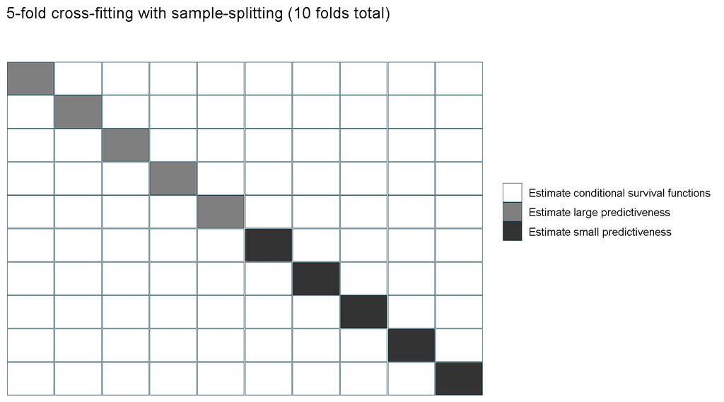

## Survival stacking

On considère une grille de temps discrète $\mathcal{T} = \{t_1,...,t_K\}$

Pour chaque individu $i$ et chaque temps $t_k \in \mathcal{T}$, on construit une observation

$$(t_k, X_i, Y_{ik}),$$
où la variable réponse binaire est définie par $Y_{ik}= 1(T_i \leq t_k).$

Le jeu de données empilé est alors définie comme :

$$\mathcal{D}_{stack}=\{(t_k,X_i,Y_{ik}): i = 1, \dots,n; k = 1, \dots, K\}$$
$\rightarrow$ Reformulation du problème de survie en problème de régression (ou classification) sur $Y_{ik}$ en fonction de $(t_k,X_i)$ :

$$F(t \mid X) = \mathbb{P}(T \leq t \mid X)$$

## Survival stacking : illustration sur les données du TCGA

```r
time_grid <- c(0, sort(unique(time)))
length(time_grid)
```

```
[1] 212
```

```r
tcga_stacked <- survML:::stack_cdf(time, X, time_grid)%>%
  dplyr::relocate(t, event_indicators)
dim(tcga_stacked)
```

```
[1] 48336    81
```

```r
length(unique(tcga_stacked$t))
```

```
[1] 212
```

```r
head(tcga_stacked %>% dplyr::filter(t == time_grid[1])%>% dplyr::select(1:5))
```

```
  t event_indicators age figo hpv_negative
1 0                0   1    1            0
2 0                0   0    0            0
3 0                0   0    0            0
4 0                0   1    0            0
5 0                0   0    0            0
6 0                0   0    1            0
```

```r
head(tcga_stacked %>% dplyr::filter(t == time_grid[90])%>% dplyr::select(1:5))
```

```
         t event_indicators age figo hpv_negative
1 18.24638                0   1    1            0
2 18.24638                0   0    0            0
3 18.24638                0   0    0            0
4 18.24638                0   1    0            0
5 18.24638                1   0    0            0
6 18.24638                0   0    1            0
```